# DATA 621 Homework 5

Group 2

### Overview

A large wine manufacturer is studying the data in order to predict the number of wine cases ordered based upon the wine characteristics. If the wine manufacturer can predict the number of cases, then that manufacturer will be able to adjust their wine offering to maximize sales.

Your objective is to build a count regression model to predict the number of cases of wine that will be sold given certain properties of the wine.

```r
knitr::opts_chunk$set(echo = TRUE)
knitr::opts_chunk$set(message = FALSE)
knitr::opts_chunk$set(warning = FALSE)
```

```r
library(dplyr)
library(reshape)
library(ggplot2)
library(purrr)
library(psych)
library(tidyr)
```

### Load Data

Load the wine training data

[output not shown]

Load the wine evaluation data

```r
# load data
eval_data <- read.csv('wine-evaluation-data.csv')
head(eval_data,2)
```

```
##   IN TARGET FixedAcidity VolatileAcidity CitricAcid ResidualSugar Chlorides
## 1  3     NA          5.4          -0.860       0.27         -10.7     0.092
## 2  9     NA         12.4           0.385      -0.76         -19.7     1.169
##   FreeSulfurDioxide TotalSulfurDioxide Density   pH Sulphates Alcohol
## 1                23                398 0.98527 5.02      0.64    12.3
## 2               -37                 68 0.99048 3.37      1.09    16.0
##   LabelAppeal AcidIndex STARS
## 1          -1         6    NA
## 2           0         6     2
```

### Describe the Data

```r
instances = dim(data)[1]
features = dim(data)[2]
cat('Dataset for this assignment is', instances, 'instances and', features, 'features')
```

```
## Dataset for this assignment is 12795 instances and 16 features
```

### Missing Values Count

```r
map(data, ~sum(is.na(.))) %>% t()
```

```
##      ï..INDEX TARGET FixedAcidity VolatileAcidity CitricAcid ResidualSugar
## [1,] 0        0      0            0               0          616
##      Chlorides FreeSulfurDioxide TotalSulfurDioxide Density pH  Sulphates
## [1,] 638       647               682                0       395 1210
##      Alcohol LabelAppeal AcidIndex STARS
## [1,] 653     0           0         3359
```

### Describe data

```r
describe(data)
```

```
##                    vars     n    mean      sd  median trimmed     mad     min
## ï..INDEX              1 12795 8069.98 4656.91 8110.00 8071.03 5977.84    1.00
## TARGET                2 12795    3.03    1.93    3.00    3.05    1.48    0.00
## FixedAcidity          3 12795    7.08    6.32    6.90    7.07    3.26  -18.10
## VolatileAcidity       4 12795    0.32    0.78    0.28    0.32    0.43   -2.79
## CitricAcid            5 12795    0.31    0.86    0.31    0.31    0.42   -3.24
## ResidualSugar         6 12179    5.42   33.75    3.90    5.58   15.72 -127.80
## Chlorides             7 12157    0.05    0.32    0.05    0.05    0.13   -1.17
## FreeSulfurDioxide     8 12148   30.85  148.71   30.00   30.93   56.34 -555.00
## TotalSulfurDioxide    9 12113  120.71  231.91  123.00  120.89  134.92 -823.00
## Density              10 12795    0.99    0.03    0.99    0.99    0.01    0.89
## pH                   11 12400    3.21    0.68    3.20    3.21    0.39    0.48
## Sulphates            12 11585    0.53    0.93    0.50    0.53    0.44   -3.13
## Alcohol              13 12142   10.49    3.73   10.40   10.50    2.37   -4.70
## LabelAppeal          14 12795   -0.01    0.89    0.00   -0.01    1.48   -2.00
## AcidIndex            15 12795    7.77    1.32    8.00    7.64    1.48    4.00
## STARS                16  9436    2.04    0.90    2.00    1.97    1.48    1.00
##                         max    range  skew kurtosis    se
## ï..INDEX           16129.00 16128.00  0.00    -1.20 41.17
## TARGET                 8.00     8.00 -0.33    -0.88  0.02
## FixedAcidity          34.40    52.50 -0.02     1.67  0.06
## VolatileAcidity        3.68     6.47  0.02     1.83  0.01
## CitricAcid             3.86     7.10 -0.05     1.84  0.01
## ResidualSugar        141.15   268.95 -0.05     1.88  0.31
## Chlorides              1.35     2.52  0.03     1.79  0.00
## FreeSulfurDioxide    623.00  1178.00  0.01     1.84  1.35
## TotalSulfurDioxide  1057.00  1880.00 -0.01     1.67  2.11
## Density                1.10     0.21 -0.02     1.90  0.00
## pH                     6.13     5.65  0.04     1.65  0.01
## Sulphates              4.24     7.37  0.01     1.75  0.01
## Alcohol               26.50    31.20 -0.03     1.54  0.03
## LabelAppeal            2.00     4.00  0.01    -0.26  0.01
## AcidIndex             17.00    13.00  1.65     5.19  0.01
## STARS                  4.00     3.00  0.45    -0.69  0.01
```

### Boxplot the data

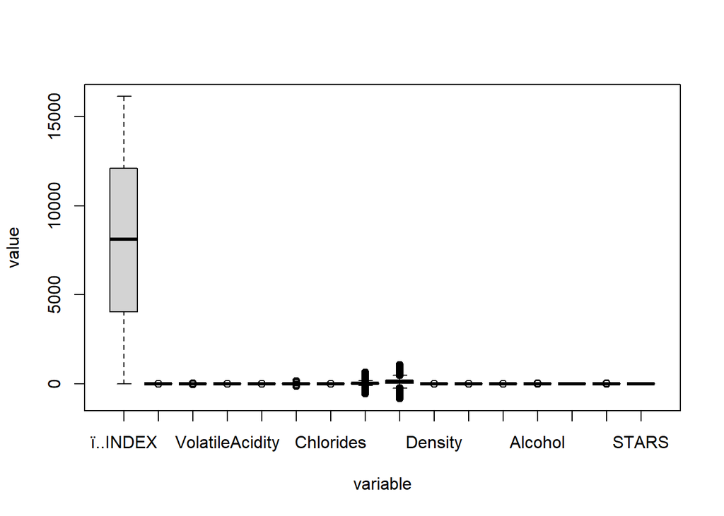

```r
meltData <- melt(data)
boxplot(data=meltData, value~variable)
```

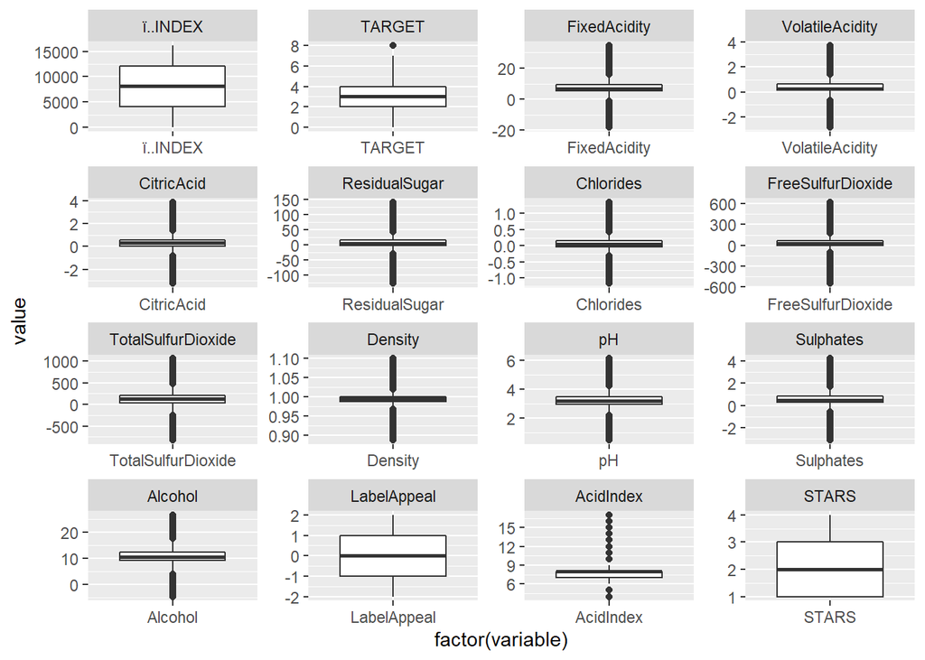

```r
p <- ggplot(meltData, aes(factor(variable), value))
p + geom_boxplot() + facet_wrap(~variable, scale="free")
```